# Assignment 3

Tiantian Yin

March 29, 2017

# Assignment 3: NY Times Op-Eds

## Part I

In this part, I explore and show how five columnists differ in the word they use. After I cleaned the texts. I plot the top 20 words that appear most frequently in all texts. “Trump” is the most frequent words among all texts written by five columnists, which occurs more than 3000 times. “Clinton” is also in the 20 words, but it only appears less than 1000 times, much less than “Trump”. As we can see, “people”, “republican”, “American” and “presid”(might stem from president, presidential or similar words) are also frequent words and tightly related with politics.

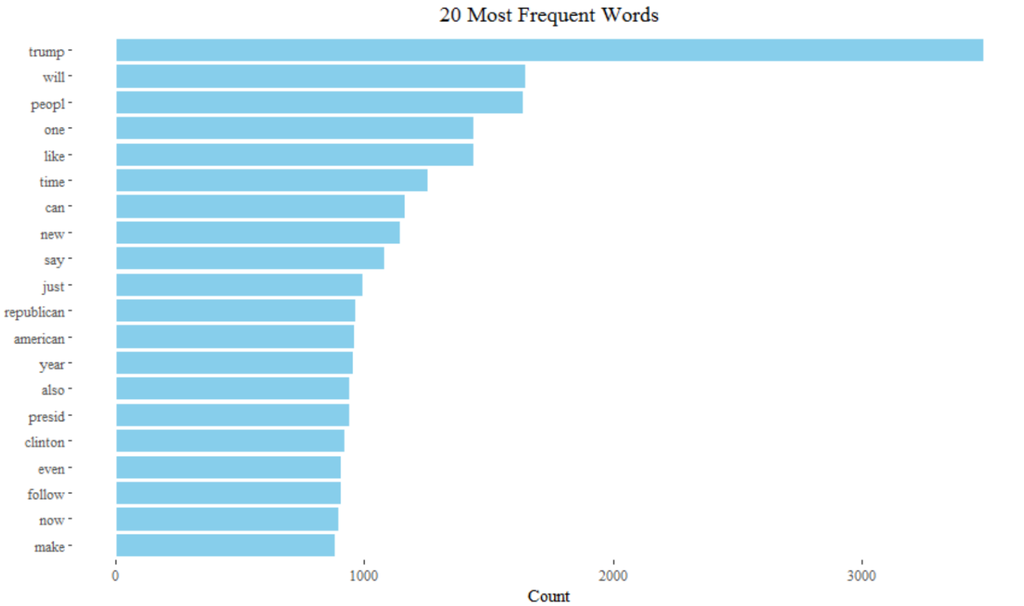

Figure1

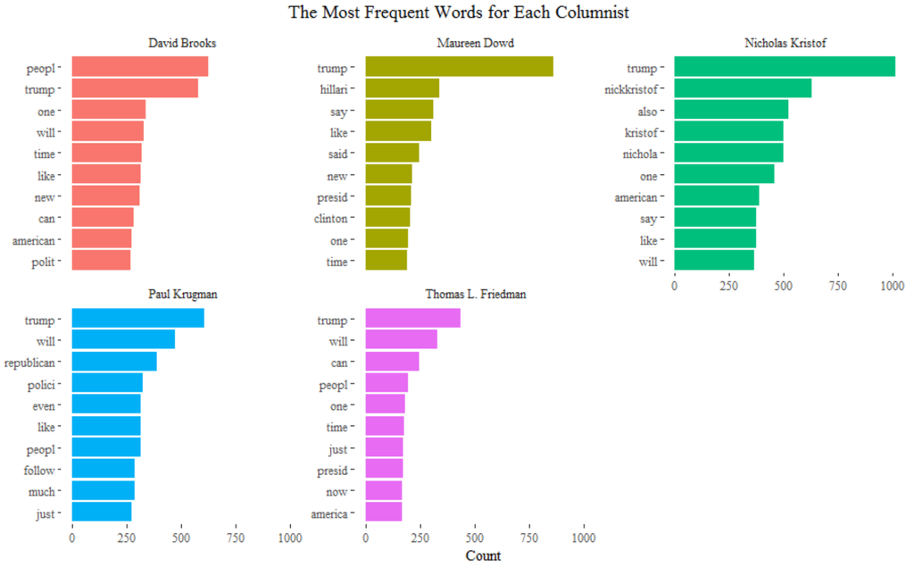

Figure2

TF-IDF is another way to compare the frequency of words. Here I show the words with highest TF-IDF for each author. But TF-IDF only shows the words appear most times in one particular article but rare in other articles in our corpus. So to explore the writing style for each author, I will still use raw frequency of words.

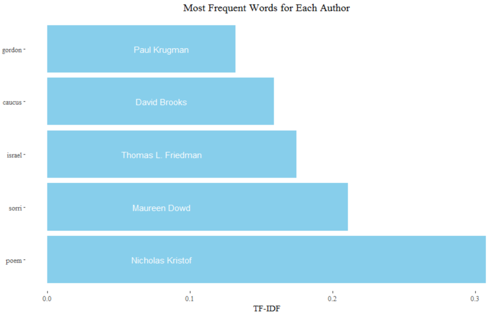

Figure3

Word Cloud is also a good way to see the writing style for each person and make comparison. This cloud shows words that columnists use differently. I noticed that for those words, they all have similar frequency in articles for five columnists. We can take a glance about the backgroud of each columnist. For example, we can see words like “tax” and “insur” in cloud for Paul Krugman as a result of he is an economist. Moreover, for the reason of Nicholas Kristof cares about human rights, we can see words like “womem”, “children”, “black” and “refuge” in his cloud.

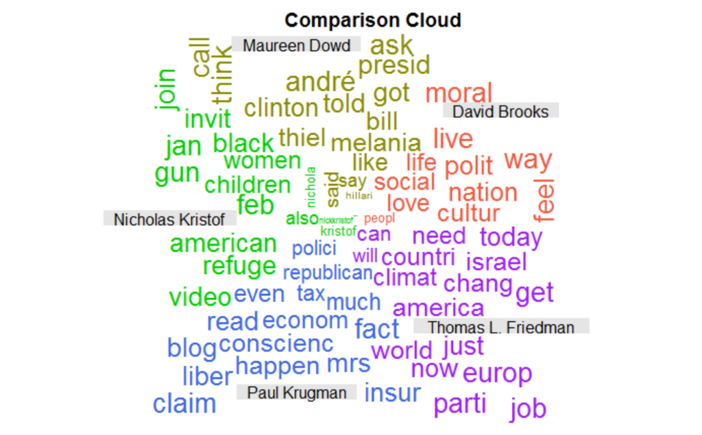

Figure4

The second cloud shows common words five columnists use. “Trump” is obviouse the most frequent common word, corresponding to what I found above. Words like “people”, “will” also have relatively higher absolutely frequent among common words for all authors.

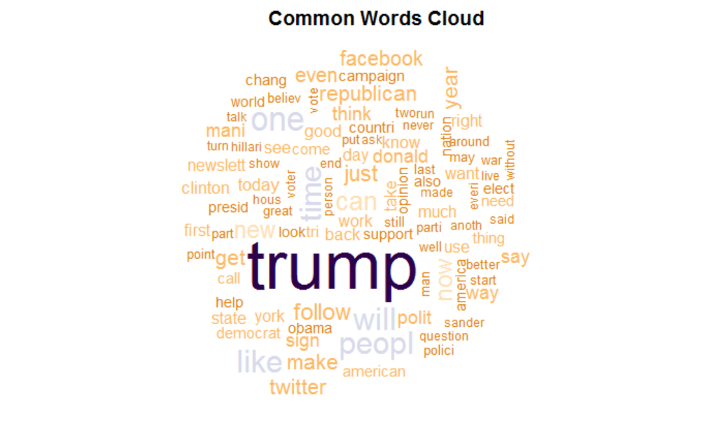

Figure5

## Part II

To compare the complexity of their writing, I compute the Flesch-Kincaid Reading Ease score for each document. Their scores are all between 0-20, which means difficult to read, but understand by university graduates. The score for Kristof changes widely, almost from 5 to 20, however, the complexity for Krugman and Brooks are relatively consistent. Kristof, Krugman and Friedman have higher scores than Dowd and Brooks in repecct of median of FRE score of their article.

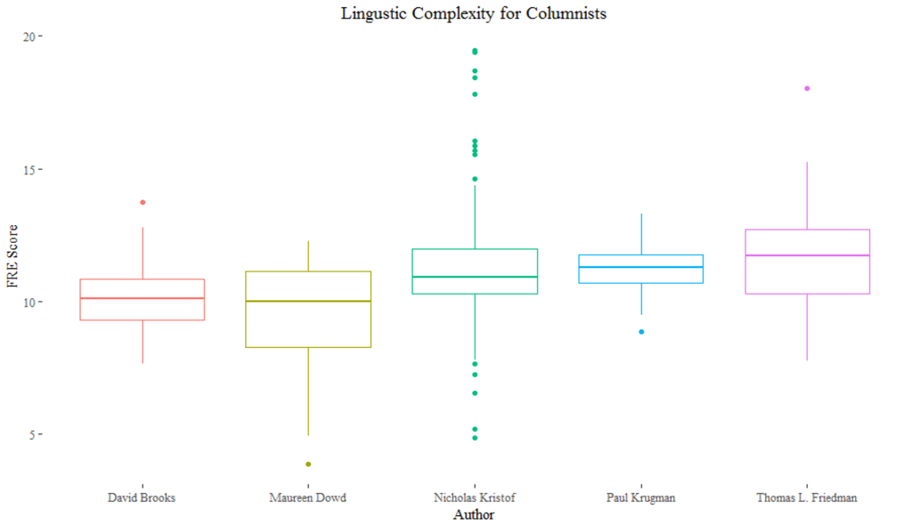

Figure6

## Part III

I compute the word associations for all articles as a whole. “Clinton” has the highest association with “Hillary” and “Bill” and “Trump” always appears with “Donald” – of course. For “Clinton”, the other words other tan “Hillary” and “Clinton” have similar association with it. But for word “Trump”, more words are more likelly to apprear with it. For example, “tower”, “mogul” and “orchestra”.

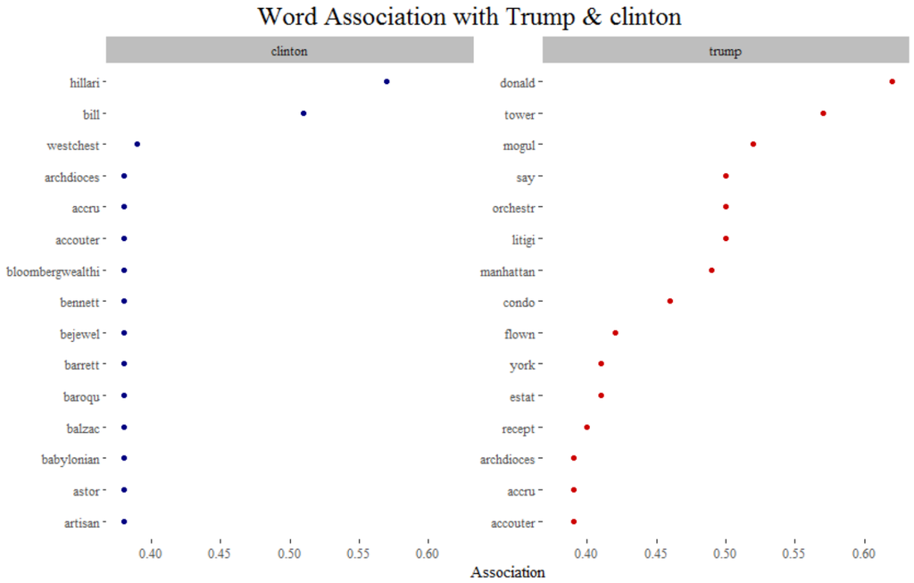

Figure7

Each columnist has different tone of the articles about candidates. For articles mentioning both candidates, the sentiment score of all authors are around 0. Dowd and Kristof have negative median score for articles about two candidates. This might suggests that all five columnists hold a neutral but slightly negative view about the election. For articles only mention one candidate, the sentiment score has obviously changes. For articles about Clinton, the score of Brooks is positive skewed, while Dowd and Kristof are negative skewed. But the tone of each columnist changes a lot for articles about Trump. Friedman has a relatively positive tone about trump comparing to other columnists.

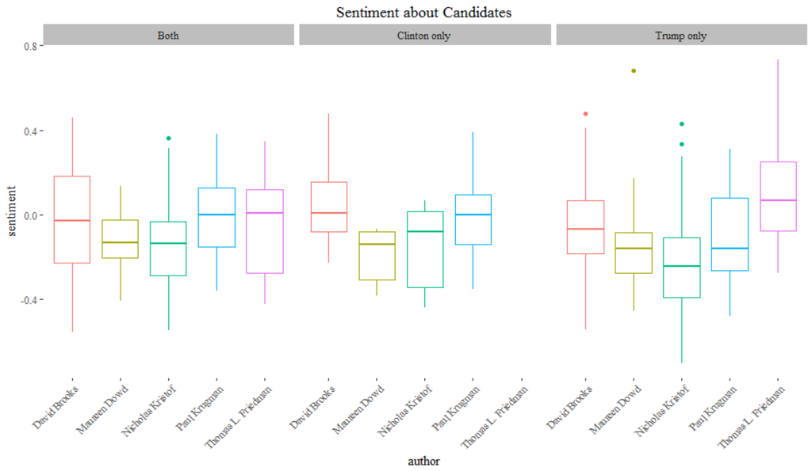

Figure8

Moreover, I assume that major political events influenced the sentiment of how columnists wrote about the two candidates. Shown by the plot below, the tone of two candidates always changes. We can see the sentiment increase after two candidates get nominated. The sentiment of Trump decreases between election day and inaugration day, but increases a little bit in recent days. Nevertheless, the date of political event and turning points of sentiment do not match that well. Thus, it is reasonable to say that the political events has limit effects on sentiment of candidates.

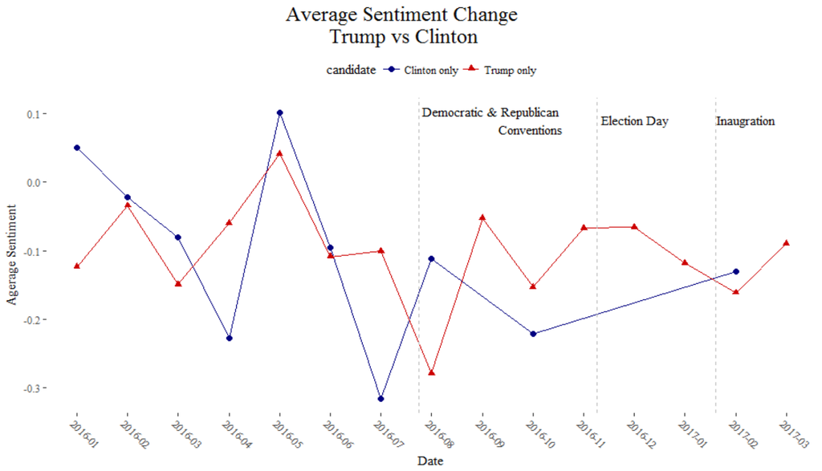

Figure9

# Project Book

```r
# Load packages
library(quanteda)
library(tm)
library(qdap)
library(SnowballC)
library(tidyverse)
library(tidytext)
library(ggplot2)
library(ggthemes)
library(wordcloud)
# Load data
load("nytimes_oped_corpus.rda")

# Rename the text
nyt.df <- corpus$documents
for (i in 1:dim(nyt.df)[1]) {
  filename <- paste0("texts/", 1000+i, nyt.df$author[i], "-", nyt.df$date[i], ".txt")
  sink(file = filename) %>% # open file to write
  cat(nyt.df[i,"texts"])  # write the file
  sink()
  print(i)
}

# Get Corpus
nyt_corpus <- VCorpus(DirSource("texts/"))

# Clean Corpus
removeNumPunct <- function(x){gsub("[^[:alpha:][:space:]]*", "", x)}
clean_corpus <- function(corpus){
  corpus <- tm_map(corpus, content_transformer(tolower))
  corpus <- tm_map(corpus, content_transformer(replace_symbol))
  corpus <- tm_map(corpus, removeWords, c(stopwords("en")))
  corpus <- tm_map(corpus, stripWhitespace)
  corpus <- tm_map(corpus, removeNumbers)
  corpus <- tm_map(corpus, content_transformer(removeNumPunct))
  return(corpus)
}
nyt_clean <- clean_corpus(nyt_corpus)

nyt_stemmed <- tm_map(nyt_clean, stemDocument) # Stem the words

nyt_tdm <- TermDocumentMatrix(nyt_stemmed) # Transform to a Term Document Matrix

nyt_td <- tidy(nyt_tdm)
nyt_td$document <- substr(nyt_td$document, 5, nchar(nyt_td$document) - 4)
nyt_td$date <- substr(nyt_td$document, nchar(nyt_td$document) - 9, nchar(nyt_td$document))
nyt_td$author <- substr(nyt_td$document, 1, nchar(nyt_td$document) - 11)
```

```r
nyt_td %>% group_by(term) %>% summarise(n = sum(count)) %>% top_n(n = 20, wt = n) %>% mutate(term = reorder(term, n)) %>% ggplot(aes(term, n)) + geom_bar(stat = "identity", color = "white", fill = "skyblue") + xlab(NULL)  + ylab("Count") + coord_flip() + theme_tufte() + ggtitle("20 Most Frequent Words") + theme(plot.title = element_text(hjust = 0.5))
```

Calculating TF-IDF

```r
# Bind the TF, DF, and IDF frequency
nyt_tf_idf <- nyt_td %>% bind_tf_idf(term, document, count) %>% arrange(desc(tf_idf))
```

```r
nyt_tf_idf %>% group_by(author) %>% top_n(n = 1, wt = tf_idf) %>% ggplot(aes(x = reorder(term, desc(tf_idf)), y = tf_idf)) + geom_bar(stat = "identity", fill = "skyblue") + geom_text(aes(label = author, x = term, y = 0.08), color = "white") + xlab(NULL) + ylab("TF-IDF") + coord_flip() + theme_tufte() + ggtitle("Most Frequent Words for Each Author") + theme(plot.title = element_text(hjust = 0.5))
```

Top Words in for each Author (TF-IDF)

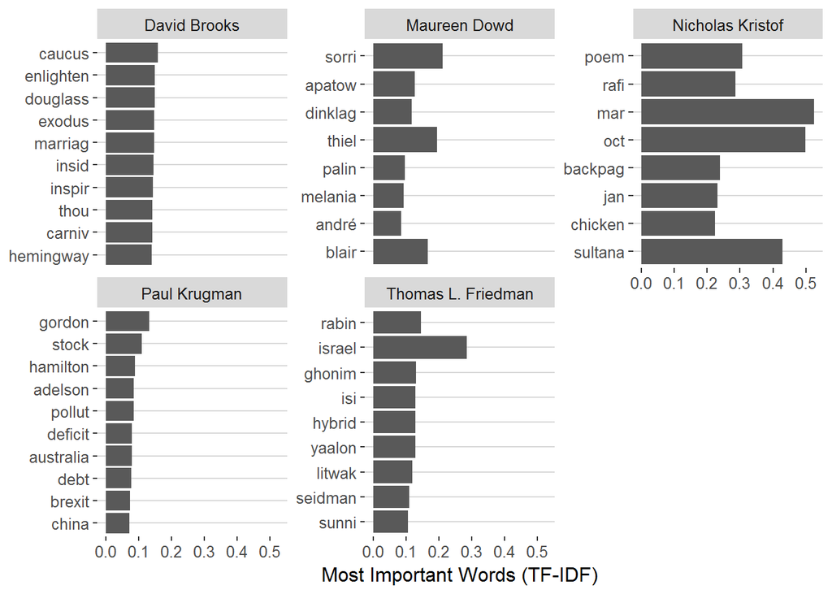

```r
nyt_tf_idf %>% group_by(author) %>% top_n(n = 10, wt = tf_idf) %>% ggplot(aes(x = reorder(term, tf_idf), y = tf_idf)) + geom_bar(stat = "identity") + coord_flip() + facet_wrap(~author, scales = "free_y") + xlab(NULL) + ylab("Most Important Words (TF-IDF)") + theme_hc()
```

For the reason I mentioned above, I think it’s better to use raw frequency in this case.

```r
a <- nyt_tf_idf %>% group_by(author, term) %>% summarise(n = sum(count))  %>% top_n(n = 10, wt = n) %>% mutate(term = reorder(term, n))
#fix the order
a1 <- a[order(a$author, a$n), ]
sn = factor(x = 1:50, labels = a1$term)
a1$sn <-sn
```

```r
a1 %>% ggplot(aes(x = sn, y = n)) + geom_bar(aes(fill = author), stat = "identity") + xlab(NULL)  + ylab("Count") + coord_flip() + facet_wrap(~author, scales = "free_y") + theme_tufte() + ggtitle("The Most Frequent Words for Each Columnist") + theme(plot.title = element_text(hjust = 0.45), legend.position = "None")
```

Word Cluoud

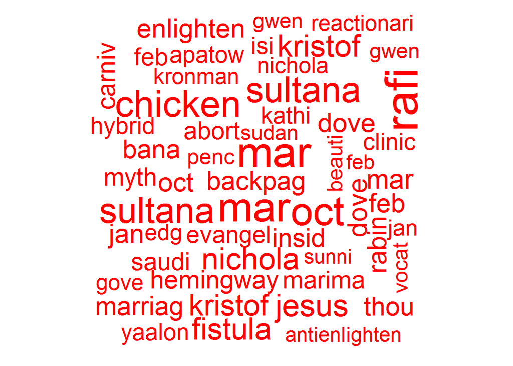

```r
set.seed(2103)
wordcloud(nyt_tf_idf$term, nyt_tf_idf$tf_idf, max.words = 100, colors = "red")
```

This cloud I plot with TF-IDF, these words are just the most common words in one particular article in corpus.

```r
# aggregate same terms in different documents
nyt_agg <- aggregate(nyt_td['count'], by=nyt_td[c('term', 'author')], sum)
nyt_five <- nyt_agg %>% spread(author, count)
nyt_five[is.na(nyt_five)] <- 0
rownames(nyt_five) <- nyt_five[,1]
nyt_five <- nyt_five[,-1]
nyt_five <- as.matrix(nyt_five)

purple_orange <- brewer.pal(10, "PuOr")
purple_orange <- purple_orange[-(1:2)]
```

```r
set.seed(500)
comparison.cloud(nyt_five, colors = c("tomato2", "yellow4", "green3", "royalblue", "purple"), scale = c(0.1,2), title.size = 1, max.words = 100) + title(main = "Comparison Cloud")


set.seed(7)
commonality.cloud(nyt_five, colors = purple_orange, max.words = 100) + title(main = "Common Words Cloud")
```

# Part III

```r
#identifiying Trump or Clinton articles
corpus$documents$trump_article <- grepl("TRUMP", corpus$documents$person, fixed = TRUE)
corpus$documents$clinton_article <- grepl("CLINTON", corpus$documents$person, fixed = TRUE)
# identify the words associations
trump_associations <- findAssocs(nyt_tdm, c("trump"), 0.2)
clinton_associations <- findAssocs(nyt_tdm, c("clinton"), 0.2)


assot <- as.data.frame(trump_associations$trump[1:15])
assot$words <- rownames(assot)
assot$candidate <- "trump"
names(assot)[names(assot) == 'trump_associations$trump[1:15]'] <- 'Association'
assoc <- as.data.frame(clinton_associations$clinton[1:15])
assoc$words <- rownames(assoc)
assoc$candidate <- "clinton"
names(assoc)[names(assoc) == 'clinton_associations$clinton[1:15]'] <- 'Association'
associations <- bind_rows(assot, assoc)
```

```r
# Figure 7 Words Association
associations %>% ggplot(aes(x = reorder(words, Association), y = Association)) + geom_point(aes(color = candidate)) + scale_color_manual(values = c("navy", "red3")) + coord_flip() + facet_wrap(~candidate, scales = "free_y") + xlab(NULL) + theme_tufte() + ggtitle("Word Association with Trump & clinton") + theme(plot.title = element_text(size = 18, hjust = 0.4), legend.position = "None") + theme(strip.background = element_rect(colour = "grey", fill = "grey"))
```

sentiment analysis – Tone

```r
pos <- read.table("C:/Users/1/Desktop/Columbia/CU/Spring 2017/Data Visualization/QMSS-G4063-Data-Visualization/Assignments/Assignment 3/dictionaries/positive-words.txt", as.is=T)
neg <- read.table("C:/Users/1/Desktop/Columbia/CU/Spring 2017/Data Visualization/QMSS-G4063-Data-Visualization/Assignments/Assignment 3/dictionaries/negative-words.txt", as.is=T)

sentiment <- function(words){
  n = length(words)
  out = rep(NA_real_, n)
  for (i in 1:n){
    tok <- quanteda::tokenize(words[i])
    pos.count <- sum(tok[[1]]%in%pos[,1])
    neg.count <- sum(tok[[1]]%in%neg[,1])
    out[i] <- (pos.count - neg.count)/(pos.count+neg.count)
  }
  return(out)
}

df <- corpus$documents
df$sentiment <- sentiment(corpus$documents$texts)

# data restructure
df$candidate[df$trump_article == TRUE & df$clinton_article == FALSE] <- "Trump only"
df$candidate[df$trump_article == FALSE & df$clinton_article == TRUE] <- "Clinton only"
df$candidate[df$trump_article == TRUE & df$clinton_article == TRUE] <- "Both"
df$candidate[df$trump_article == FALSE & df$clinton_article == FALSE] <- "None"
```

```r
#Figure 8
df %>% filter(candidate != "None") %>% ggplot(aes(x = author, y = sentiment)) + geom_boxplot(aes(color = author)) + theme_tufte() + facet_wrap(~candidate) + theme(axis.text.x = element_text(angle = 45, hjust = 1)) + ggtitle("Sentiment about Candidates") + theme(plot.title = element_text(hjust = 0.5), legend.position = "None", strip.background = element_rect(colour = "grey", fill = "grey"))
```

```r
nyt_td$document <- substr(nyt_td$document, 5, nchar(nyt_td$document) - 4)
df$month <- substr(df$date, 1, nchar(df$date) - 3)
# compute the average sentiment over each month
change <- df %>% filter(candidate == "Trump only" | candidate == "Clinton only") %>% group_by(candidate, month) %>% summarise(ave_sentiment = mean(sentiment))
```

```r
# Figure 9 Effects of Political Events
change %>% ggplot(aes(x = month, y = ave_sentiment)) + geom_line(aes(group = candidate, color = candidate)) + geom_point(aes(shape = candidate, color = candidate), size = 2) + scale_colour_manual(values = c("navy", "red3")) + theme_tufte() + ggtitle("Average Sentiment Change \n Trump vs Clinton") + theme(legend.position = "top") + theme(axis.text.x = element_text(angle = -45, hjust = 0)) + xlab("Date") + ylab("Agerage Sentiment") + theme(plot.title = element_text(size = 18, hjust = 0.45)) + geom_vline(xintercept = c(7.75, 11.27, 13.6), lty=2, color ="grey") + annotate("text", x = c(10.58, 12.68, 14.78), y = 0.09,
           adj=1,  family="serif",
           label = c("Democratic & Republican \n Conventions", "Election Day", "Inaugration"))
```